# **TEAMWORK** :sparkles:

## Table of Contents

- THE TEAM
- *DIVISION OF LABOUR*
- *GRADED PULL REQUESTS PAIRING*
- *TIMING*
- *COMMUNICATION*

## THE TEAM

### Our Team is located on UBC campus

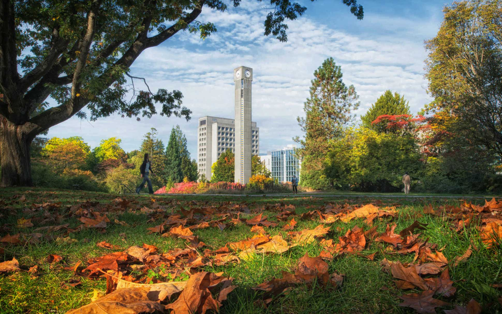

UBC Campus

### We have 5 members:

1. Kevin
2. Danielle :black_cat:
3. Sasha
4. Jonathan
5. Taysia :seedling:

## *DIVISION OF LABOUR*

Kevin: Set up repo and provide initial drafts for documents

Danielle: Set up group chat (group admin). Established groups “GRADED pull request” format as adding an emoji to our name. Will also revise the rubric prior to submission and confirm with the group that we have hit all points on the rubric.

Taysia: Added to the TEAMWORK file and handled merge conflicts in my branch caused by multiple updates to the main branch

### *GRADED PULL REQUESTS PAIRING*

The pull request is to add an emoji next to your name under THE TEAM

| ENTERS PULL REQUEST | ACCEPTS PULL REQUEST |
| --- | --- |
| DANIELLE | SASHA |
| KEVIN | DANIELLE |
| TAYSIA | KEVIN |
| JONATHAN | TAYSIA |
| SASHA | JONATHAN |

## *TIMING*

Pull requests will be submitted 24 hours prior to deadline of assignment to allow for adequate time to debug.

## *COMMUNICATION*

The team will use Slack for real-time discussions and GitHub Issues for task-specific communication and tracking progress. Slack will be used for quick questions, coordination, and for planning division of labour, while GitHub Issues will store decisions and detailed technical discussions. Team members will aim to respond to Slack messages and Github issues in a timely manner to able to complete the assignment on time. **We will hold a virtual check-in meetings when needed to discuss progress and next steps, these meetings will be held through our [Slack huddle group](https://app.slack.com/huddle/T09A488KAUT/C09EX911AEQ).**